# Denver Colorado Maximum Annual Temperature from 1948-2024.

## Data Source

This data[1] is drawn from The Global Historical Climatology Network - Daily (GHCN-Daily/GHCNd) dataset[2](https://www.ncei.noaa.gov/metadata/geoportal/rest/metadata/item/gov.noaa.ncdc:C00861/html) which integrates daily climate observations from approximately 30 different land surface sources from around the world.

According to the National Centers for Environmental Information[2](https://www.ncei.noaa.gov/metadata/geoportal/rest/metadata/item/gov.noaa.ncdc:C00861/html), "the dataset cannot be used to quantify all aspects of climate variability and change without any additional processing. In general, the stations providing daily observations were not managed to meet the desired standards for climate monitoring. Rather, the stations were deployed to meet the demands of agriculture, hydrology, weather forecasting, aviation, etc."

For this analysis I selected data station # USW00023062 located in Denver Central Park, Colorado. This station is the only one in the area with datasets going back over half a century, in this case to 1948. Unfortunately, the TOBS data had large gaps so I instead looked at the TMAX data for evidence of climate change.

[1]: Menne, Matthew J., Imke Durre, Bryant Korzeniewski, Shelley McNeill, Kristy Thomas, Xungang Yin, Steven Anthony, Ron Ray, Russell S. Vose, Byron E. Gleason, and Tamara G. Houston (2012): Global Historical Climatology Network - Daily (GHCN-Daily), Version 3, Denver Central Park, CO, Station USW00023062. NOAA National Climatic Data Center. doi:10.7289/V5D21VHZ [accessed Sept 23, 2024].

```python
# Import required packages
import pandas as pd
```

```python
denver_url = (
    'https://www.ncei.noaa.gov/access/services/data/v1?'
    'dataset=daily-summaries'
    '&dataTypes=TMAX,PRCP&stations=USW00023062'
    '&startDate=1948-01-01'
    '&endDate=2024-09-10'
    '&units=standard')
denver_url
```

```
'https://www.ncei.noaa.gov/access/services/data/v1?dataset=daily-summaries&dataTypes=TMAX,PRCP&stations=USW00023062&startDate=1948-01-01&endDate=2024-09-10&units=standard'
```

```python
# Import data into Python from NCEI API
pd.read_csv(
    denver_url,
    index_col='DATE',
    parse_dates=True)
```

| DATE | STATION | PRCP | TMAX |
| --- | --- | --- | --- |
| 1948-01-01 | USW00023062 | 0.0 | 43.0 |
| 1948-01-02 | USW00023062 | 0.0 | 47.0 |
| 1948-01-03 | USW00023062 | 0.0 | 56.0 |
| 1948-01-04 | USW00023062 | 0.0 | 57.0 |
| 1948-01-05 | USW00023062 | 0.0 | 53.0 |
| ... | ... | ... | ... |
| 2024-08-31 | USW00023062 | 0.0 | 87.0 |
| 2024-09-02 | USW00023062 | 0.0 | 87.0 |
| 2024-09-03 | USW00023062 | 0.0 | 91.0 |
| 2024-09-09 | USW00023062 | 0.0 | 88.0 |
| 2024-09-10 | USW00023062 | 0.0 | 90.0 |

27976 rows × 3 columns

```python
# Download the climate data
denver_df = pd.read_csv(
    denver_url,
    index_col='DATE',
    parse_dates=True,
    na_values=['NaN'])
denver_df
```

| DATE | STATION | PRCP | TMAX |
| --- | --- | --- | --- |
| 1948-01-01 | USW00023062 | 0.0 | 43.0 |
| 1948-01-02 | USW00023062 | 0.0 | 47.0 |
| 1948-01-03 | USW00023062 | 0.0 | 56.0 |
| 1948-01-04 | USW00023062 | 0.0 | 57.0 |
| 1948-01-05 | USW00023062 | 0.0 | 53.0 |
| ... | ... | ... | ... |
| 2024-08-31 | USW00023062 | 0.0 | 87.0 |
| 2024-09-02 | USW00023062 | 0.0 | 87.0 |
| 2024-09-03 | USW00023062 | 0.0 | 91.0 |
| 2024-09-09 | USW00023062 | 0.0 | 88.0 |
| 2024-09-10 | USW00023062 | 0.0 | 90.0 |

27976 rows × 3 columns

### Data Cleanup

Below, I am specifying the specific data I want to examine, in this case the maximum temperatures.

```python
denver_df = denver_df[['TMAX']]
denver_df
```

| DATE | TMAX |
| --- | --- |
| 1948-01-01 | 43.0 |
| 1948-01-02 | 47.0 |
| 1948-01-03 | 56.0 |
| 1948-01-04 | 57.0 |
| 1948-01-05 | 53.0 |
| ... | ... |
| 2024-08-31 | 87.0 |
| 2024-09-02 | 87.0 |
| 2024-09-03 | 91.0 |
| 2024-09-09 | 88.0 |
| 2024-09-10 | 90.0 |

27976 rows × 1 columns

### Add Correct Units to the Data

Data was downloaded in the 'standard' format where temperatures are recorded in degrees Fahrenheit. I added this lable.

```python
denver_df_u = denver_df.rename(columns={
    'TMAX': 'TMAX_F',
})
denver_df_u
```

| DATE | TMAX_F |
| --- | --- |
| 1948-01-01 | 43.0 |
| 1948-01-02 | 47.0 |
| 1948-01-03 | 56.0 |
| 1948-01-04 | 57.0 |
| 1948-01-05 | 53.0 |
| ... | ... |
| 2024-08-31 | 87.0 |
| 2024-09-02 | 87.0 |
| 2024-09-03 | 91.0 |
| 2024-09-09 | 88.0 |
| 2024-09-10 | 90.0 |

27976 rows × 1 columns

### Plot the Results

```python
import holoviews as hv
import hvplot.pandas
```

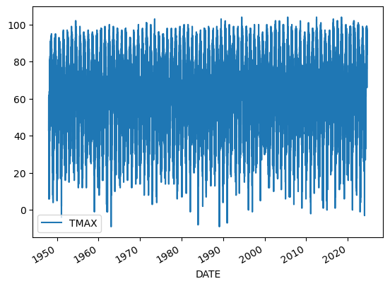

```python
denver_df.plot()
```

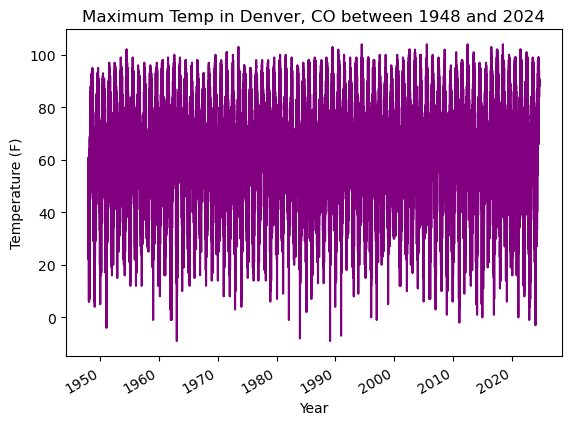

```python
# Plot the data using .plot
denver_df.plot(
    y='TMAX',
    title='Maximum Temp in Denver, CO between 1948 and 2024',
    xlabel='Year',
    ylabel='Temperature (F)',
    legend=False,
    fontsize=10,
    color='purple',
    )
```

## Resample Data

I resampled the data from the start of each year, selecting only the maximum temperature. This will make any visuals easier to read.

```python
# Clean up data by changing it to Annual Average
ann_denver_df = denver_df.resample('YS').max()
ann_denver_df
```

| DATE | TMAX |
| --- | --- |
| 1948-01-01 | 95.0 |
| 1949-01-01 | 95.0 |
| 1950-01-01 | 93.0 |
| 1951-01-01 | 97.0 |
| 1952-01-01 | 97.0 |
| ... | ... |
| 2020-01-01 | 99.0 |
| 2021-01-01 | 102.0 |
| 2022-01-01 | 101.0 |
| 2023-01-01 | 99.0 |
| 2024-01-01 | 99.0 |

77 rows × 1 columns

## Plot the Data

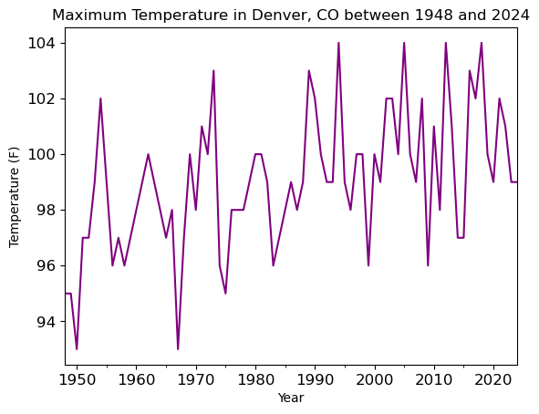

```python
# Plot the annual data

ann_denver_df.plot(
    y='TMAX',
    title='Maximum Temperature in Denver, CO between 1948 and 2024',
    xlabel='Year',
    ylabel='Temperature (F)',
    legend=False,
    fontsize=12,
    color='purple',
)
```

## Make the Plot Interactive

```python
# Plot the annual data interactively
ann_temp_plot = ann_denver_df.hvplot(
    y='TMAX',
    title='Yearly High Temperature in Denver, CO (1948 and 2024)',
    xlabel='Year',
    ylabel='Temperature (F)',
    legend=False,
    fontsize=12,
    color='purple',
)
ann_temp_plot
```

[output not shown]

## Establish a Trend Line for High Temps in Denver (1948-2024)

```python
# Advanced options on matplotlib/seaborn/pandas plots
import matplotlib.pyplot as plt
# Common statistical plots for tabular data
import seaborn as sns
# Fit an OLS linear regression
from sklearn.linear_model import LinearRegression
```

The sample data indicated that there was a 100% complete dataset for TMAX. However, I added a filter to exclude years that had less than 99% complete data. This will exclude the partial year of 2024.

```python
include = denver_df.TMAX.resample('YS').count() / 365 > .99
```

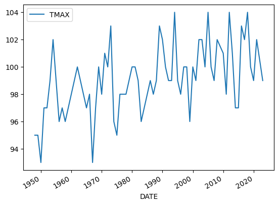

```python
from sklearn.linear_model import LinearRegression
import pandas as pd
ann_denver_df = (
    ann_denver_df
    [include]
    .dropna()
)
ann_denver_df.plot(y='TMAX')
```

```python
# Reset index to make 'Year' a column if it's currently the index
ann_denver_df = ann_denver_df.reset_index()

# Define the independent variable (X) and the dependent variable (y)
x = ann_denver_df['DATE'].dt.year.values.reshape(-1, 1) # To select just the year and not seconds since 1970
y = ann_denver_df['TMAX']

# Create and fit the model
model = LinearRegression()
model.fit(x, y)

# Get the slope (coefficient) and intercept
slope = model.coef_[0]
intercept = model.intercept_

# Print results
print(f"Slope: {slope}")
print(f"Intercept: {intercept}")
```

```
Slope: 0.05931935945312204
Intercept: -18.6899508756983
```

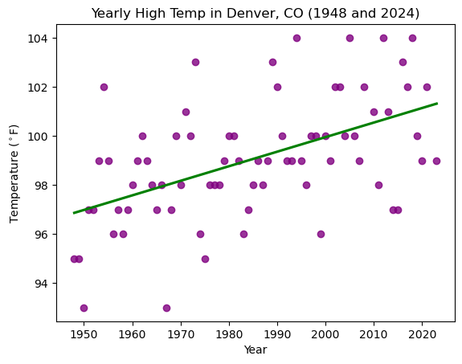

```python
# Plot annual average temperature data with a trend line
ax = sns.regplot(
    x=ann_denver_df.DATE.dt.year,
    y=ann_denver_df.TMAX,
    ci=None, # Removed the confidence interval (because this is for a extreme temp)
    color='purple', # Color of the regression line and scatter points
    line_kws={'color': 'green'},  # Change the color of the x_estimator line (mean in this case)
    scatter_kws={'color': 'purple'},  # Scatter plot points color
    )
# Set plot labels
ax.set(
    title='Yearly High Temp in Denver, CO (1948 and 2024)',
    xlabel='Year',
    ylabel='Temperature ($^\circ$F)'
)
# Display the plot without extra text
plt.show()
```

This models shows a slight but clear trend upwards in terms of the highest annual temperature in Denver Colorado during the past 70 years. While not strictly linear, the trend indicates a tendency toward higher max temperatures. The next step would be to repeat this analysis with TMIN to see if the minimum temperatures are also rising or if weather is becoming more extreme in terms of both hot and cold.